# Neotoma Resources on Chickasaw Reservation and with Chickasaw Cultural Affiliation

April 2024

## Introduction

### About [Neotoma](https://neotomadb.org)

[Neotoma](https://neotomadb.org) was formed in 2006 as a federated database constituted by a set of more specialized paleoecological databases. This means that Neotoma brings together paleoecological data from a range of proxy types (e.g., pollen, charcoal, testate amoebae), regions (e.g., North America, Latin America, Europe), and time periods (e.g., Pliocene, Pleistocene, Holocene). Neotoma incorporates data collected over more than 150 years.

## Neotoma and Native Lands

Neotoma contains records from upwards of 22,000 sites. Many of these sites are affiliated with native lands. A subset of these sites comes from federally recognized reservations in the United States.

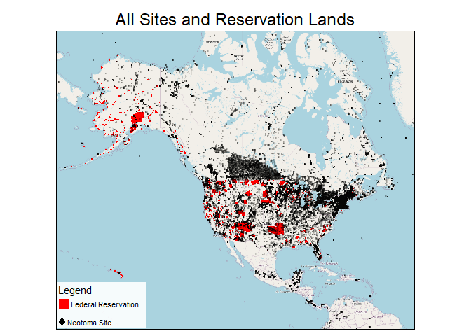

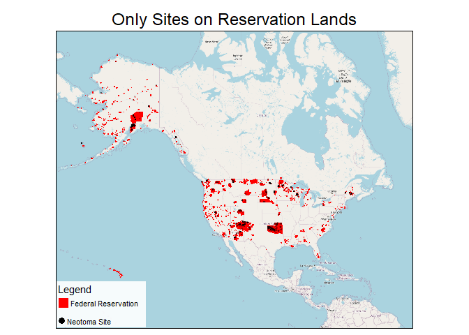

The following table counts the number of sites (n) from Neotoma that fall within the borders of federally recognized reservations. Overall, there are 692 sites on 105 reservations. The Chickasaw reservation has several Neotoma sites.

| NAME | n |
| --- | --- |
| Navajo Nation | 177 |
| Menominee | 61 |
| Chickasaw | 30 |
| Cheyenne-Arapaho | 28 |
| Hopi | 21 |
| White Earth | 19 |
| Kenaitze | 18 |
| Blackfeet | 15 |
| Cherokee | 15 |
| Kiowa-Comanche-Apache-Fort Sill Apache | 13 |

[output cut: 95 more lines]

## Neotoma Resources on the Chickasaw Reservation

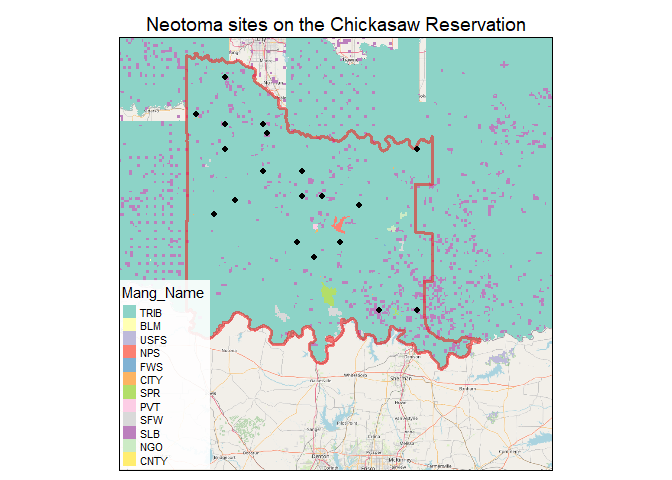

And the following table lists some information about those sites.

| siteid | sitename | sitedescription |
| --- | --- | --- |
| 3805 | Roulston-Rogers [SM-20] |  |
| 3806 | Lee II [34Gv-4] |  |
| 3810 | Lee [34Gv3] |  |
| 3814 | James [34Br-11] |  |
| 3815 | Grant [34Gv2] |  |
| 3823 | Robertson [34Gd-144] |  |
| 3824 | Williams [34Gd-122] |  |
| 3825 | O'Neal [34Gd145] |  |
| 3826 | Lindsay-Murray Mansion [34Gv-147] |  |
| 3827 | Sterr [34Gd-26] |  |

[output cut: 24 more lines]

We can further inspect the sites by the kinds of data they contain. Neotoma sites from the Chickasaw Reservation concern vertebrate fauna, macroinvertebrate, diatom and water chemistry.

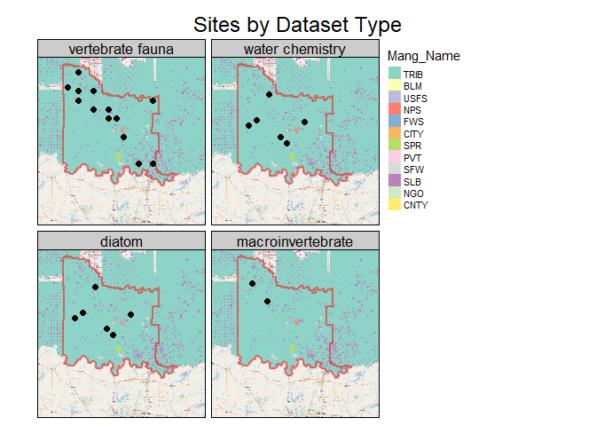

| data.datasettype | n |
| --- | --- |
| vertebrate fauna | 33 |
| macroinvertebrate | 8 |
| diatom | 6 |
| water chemistry | 6 |

Physical specimens are not typically preserved for all types of datasets, and Neotoma doesn’t have perfect information about the disposition of the physical specimens even when they do exist. What we do know is that for Neotoma data collected from the Chickasaw Reservation, the University of Oklahoma and Oklahoma Archeological Survey hold physical specimens.

| repository | types | n |
| --- | --- | --- |
| University of Oklahoma | vertebrate fauna | 16 |
| Oklahoma Archeological Survey | vertebrate fauna | 8 |

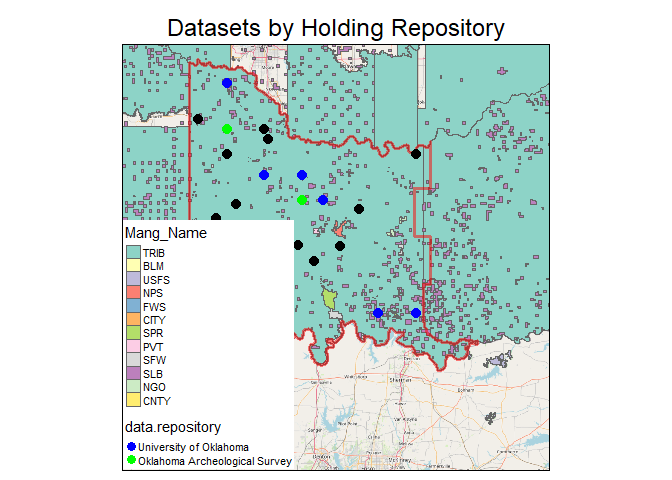

## Other Neotoma resources with Chickasaw Cultural Affiliation

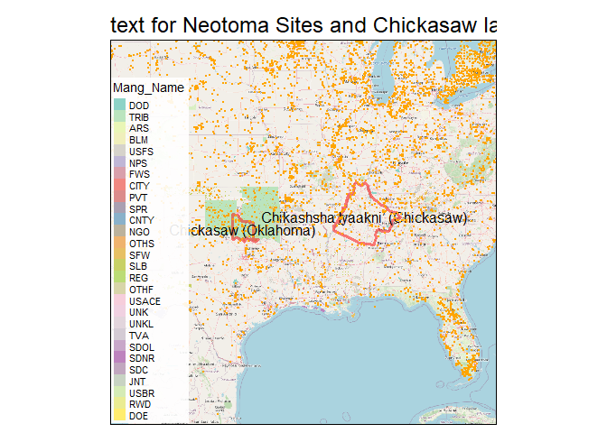

On these other lands with Chickasaw cultural affiliation (named Chickasaw (Oklahoma) and Chikashsha I̠yaakni’ (Chickasaw) on the native-land.ca website), there are 85 distinct sites with data on a range of proxy types. The repositories associated with the physical specimens for these datasets are more various compared to those on the Chickasaw Reservation.

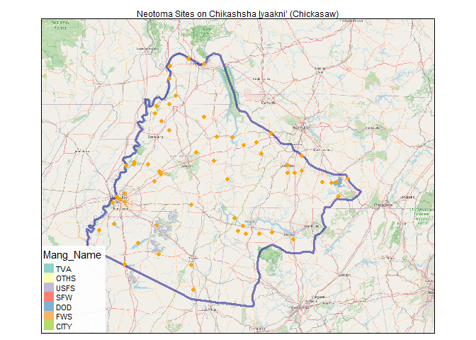

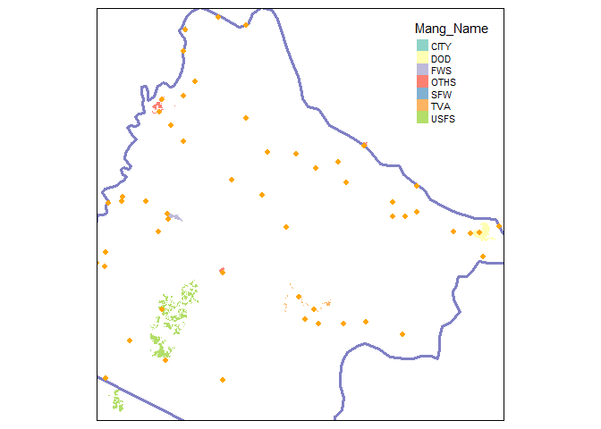

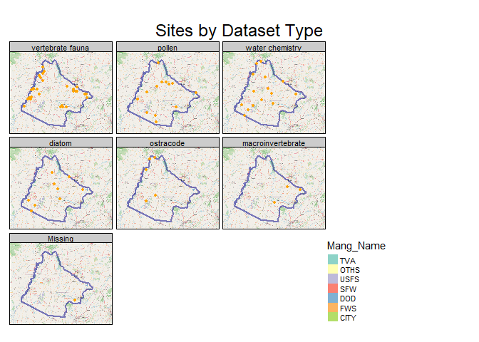

| data.datasettype | n |
| --- | --- |
| vertebrate fauna | 33 |
| water chemistry | 18 |
| pollen | 13 |
| diatom | 10 |
| ostracode | 8 |
| macroinvertebrate | 3 |
| geochemistry | 1 |

| repository | data.datasettype | n |
| --- | --- | --- |
| McClung Museum of Natural History &amp; Culture | vertebrate fauna | 3 |
| Memphis Natural History Museum | vertebrate fauna | 3 |
| Tennessee State Museum | vertebrate fauna | 3 |
| Tennessee Division of Archaeology | vertebrate fauna | 2 |
| University of Michigan Museum of Anthropology | vertebrate fauna | 2 |
| University of Tennessee | vertebrate fauna | 2 |
| Academy of Natural Sciences, Philadelphia | vertebrate fauna | 1 |
| Centerville Public Library | vertebrate fauna | 1 |
| Jewel Cave Tennessee | vertebrate fauna | 1 |
| National Museum of Natural History | vertebrate fauna | 1 |

[output cut: 9 more lines]

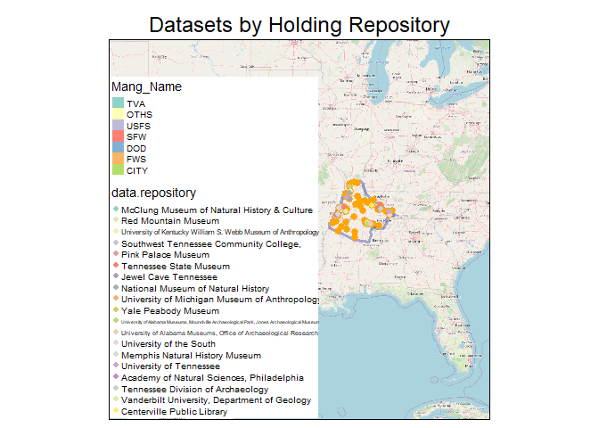